# Bagging

Nik Bear Brown

In this lesson we’ll learn the how to implement Bagging in R.

# Additional packages needed

To run the code you may need additional packages.

- If necessary install the followings packages.

`install.packages('randomForest');`  
`install.packages('caret');`  
`install.packages('rpart');`  
`install.packages('adabag');`  
`install.packages('ipred');`

```r
library(randomForest)
library(caret)
library(rpart)
library(adabag)
library(ipred)
```

# Data

We will be using the [UCI Machine Learning Repository: Adult Data](https://archive.ics.uci.edu/ml/datasets/Adult) to predict whether income exceeds $50K/yr based on census data. Also known as “Census Income” dataset.

```r
data_url <- 'http://nikbearbrown.com/YouTube/MachineLearning/M09/adult.data.txt'
# Adult data set from UCI
adult<- read.csv(url(data_url), header=FALSE)
head(adult)
```

```
##   V1                V2     V3         V4 V5                  V6
## 1 39         State-gov  77516  Bachelors 13       Never-married
## 2 50  Self-emp-not-inc  83311  Bachelors 13  Married-civ-spouse
## 3 38           Private 215646    HS-grad  9            Divorced
## 4 53           Private 234721       11th  7  Married-civ-spouse
## 5 28           Private 338409  Bachelors 13  Married-civ-spouse
## 6 37           Private 284582    Masters 14  Married-civ-spouse
##                   V7             V8     V9     V10  V11 V12 V13
## 1       Adm-clerical  Not-in-family  White    Male 2174   0  40
## 2    Exec-managerial        Husband  White    Male    0   0  13
## 3  Handlers-cleaners  Not-in-family  White    Male    0   0  40
## 4  Handlers-cleaners        Husband  Black    Male    0   0  40
## 5     Prof-specialty           Wife  Black  Female    0   0  40
## 6    Exec-managerial           Wife  White  Female    0   0  40
##              V14    V15
## 1  United-States  <=50K
## 2  United-States  <=50K
## 3  United-States  <=50K
## 4  United-States  <=50K
## 5           Cuba  <=50K
## 6  United-States  <=50K
```

```r
names(adult)
```

```
##  [1] "V1"  "V2"  "V3"  "V4"  "V5"  "V6"  "V7"  "V8"  "V9"  "V10" "V11"
## [12] "V12" "V13" "V14" "V15"
```

```r
adult.len <- sample(1:nrow(adult), 3*nrow(adult)/4)
head(adult.len)
```

```
## [1]  9708 21393 28038 25426  2925 31111
```

```r
train <- adult[adult.len,]
test <- adult[-adult.len,]
head(train)
```

```
##       V1                V2     V3            V4 V5                  V6
## 9708  43         Local-gov 269733       HS-grad  9           Separated
## 21393 38           Private 368140     Bachelors 13  Married-civ-spouse
## 28038 20                 ? 163665       HS-grad  9       Never-married
## 25426 41  Self-emp-not-inc 157686  Some-college 10  Married-civ-spouse
## 2925  40           Private 220460       HS-grad  9       Never-married
## 31111 40           Private 305846  Some-college 10  Married-civ-spouse
##                     V7             V8     V9     V10 V11 V12 V13
## 9708     Other-service  Not-in-family  White    Male   0   0  40
## 21393  Exec-managerial        Husband  White    Male   0   0  50
## 28038                ?      Own-child  White  Female   0   0  20
## 25426  Exec-managerial        Husband  White    Male   0   0  40
## 2925      Craft-repair  Not-in-family  White    Male   0   0  40
## 31111     Adm-clerical           Wife  White  Female   0   0  40
##                  V14    V15
## 9708   United-States  <=50K
## 21393  United-States   >50K
## 28038  United-States  <=50K
## 25426  United-States   >50K
## 2925          Canada  <=50K
## 31111  United-States   >50K
```

```r
head(test)
```

```
##    V1                V2     V3          V4 V5                  V6
## 14 32           Private 205019  Assoc-acdm 12       Never-married
## 15 40           Private 121772   Assoc-voc 11  Married-civ-spouse
## 17 25  Self-emp-not-inc 176756     HS-grad  9       Never-married
## 18 32           Private 186824     HS-grad  9       Never-married
## 40 48  Self-emp-not-inc 265477  Assoc-acdm 12  Married-civ-spouse
## 41 31           Private 507875         9th  5  Married-civ-spouse
##                    V7             V8                  V9   V10 V11 V12 V13
## 14              Sales  Not-in-family               Black  Male   0   0  50
## 15       Craft-repair        Husband  Asian-Pac-Islander  Male   0   0  40
## 17    Farming-fishing      Own-child               White  Male   0   0  35
## 18  Machine-op-inspct      Unmarried               White  Male   0   0  40
## 40     Prof-specialty        Husband               White  Male   0   0  40
## 41  Machine-op-inspct        Husband               White  Male   0   0  43
##               V14    V15
## 14  United-States  <=50K
## 15              ?   >50K
## 17  United-States  <=50K
## 18  United-States  <=50K
## 40  United-States  <=50K
## 41  United-States  <=50K
```

# Bootstrap aggregating (bagging)

Create ensembles by [bootstrap aggregation](https://en.wikipedia.org/wiki/Bootstrap_aggregating), i.e., repeatedly randomly re-sampling training data. Not that bagging uses the same learner so bias related to the method isn’t addressed by this approach.

Bootstrap: draw n items from X with replacement

Bootstrap aggregating: combines random learners (often with voting, averaging or median) to create a predictor lesss efected by noise. Unstable and/or noisy algorithms often profit from bagging.

Bagging’s usefulness depends on the stability of the base classifiers. If small changes in the sample cause small changes in the base-level classifier, then the ensemble will not be much better than the base classifiers. It reduces variance and helps to avoid overfitting. It is often applied to decision tree methods (random forests) and nearest neighbor classifiers, but it can be used with any type of method.

# Bagging in R

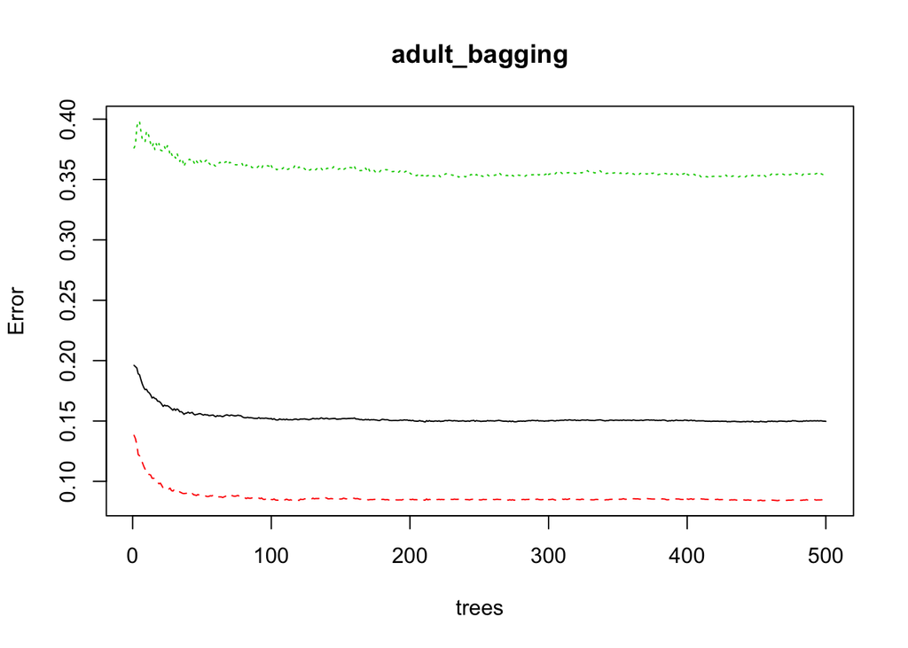

```r
adult_bagging <- randomForest(V15~.,data=adult, subset=adult.len, mtry=14, importance=TRUE)
plot(adult_bagging)
```

```r
adult_predict <- predict(adult_bagging, test)
adult_predict_confusion <- confusionMatrix(adult_predict, test$V15)
adult_predict_confusion$table
```

```
##           Reference
## Prediction  <=50K  >50K
##      <=50K   5714   710
##      >50K     504  1213
```

```r
accuracy <- adult_predict_confusion$overall[1]
accuracy
```

```
##  Accuracy
## 0.8508783
```

```r
# importance of predictors
adult_bagging$importance
```

```
##            <=50K          >50K MeanDecreaseAccuracy MeanDecreaseGini
## V1  0.0039262255  5.880092e-02         0.0172167162       1065.12142
## V2  0.0040180137  3.360404e-03         0.0038588321        317.10982
## V3  0.0003580588  1.270361e-04         0.0003021986       1608.34846
## V4  0.0195304481 -4.554646e-05         0.0147912188        385.74918
## V5  0.0258588471  1.289709e-02         0.0227192027        710.39695
## V6  0.0351790174 -3.978770e-03         0.0256934567         77.16887
## V7  0.0117681878  4.754799e-02         0.0204335694        727.95136
## V8  0.0577179881  8.800719e-02         0.0650507330       1876.67811
## V9  0.0005633864  1.473047e-03         0.0007834863         95.97174
## V10 0.0045282811 -7.225139e-04         0.0032575566         58.71537
## V11 0.0324736544  7.179697e-02         0.0419964725        952.66790
## V12 0.0046477301  2.565901e-02         0.0097360325        282.89910
## V13 0.0023908786  2.272822e-02         0.0073168687        598.56357
## V14 0.0016272250 -4.431047e-04         0.0011247528        211.44683
```

```r
# ipred package
adult_bagging <- ipredbagg(train$V15, X=train[,-15], nbagg=25,
                           control=rpart.control(minsplit=2, cp=0, xval=0),
                           comb=NULL, coob=FALSE, ns=length(train$V15), keepX = TRUE)
adult_predict <- predict(adult_bagging, test)
adult_predict_confusion <- confusionMatrix(adult_predict, test$V15)
adult_predict_confusion$table
```

```
##           Reference
## Prediction  <=50K  >50K
##      <=50K   5760   746
##      >50K     458  1177
```

```r
accuracy <- adult_predict_confusion$overall[1]
accuracy
```

```
##  Accuracy
## 0.8521066
```

# Resources

- [Improve Predictive Performance in R with Bagging via @rbloggers](http://www.r-bloggers.com/improve-predictive-performance-in-r-with-bagging/)
- [bagging {adabag} | inside-R | A Community Site for R](http://www.inside-r.org/packages/cran/adabag/docs/bagging)
- [bagging {ipred} | inside-R | A Community Site for R](http://www.inside-r.org/packages/cran/ipred/docs/bagging)
- [Bagging / Bootstrap Aggregation with R](http://amunategui.github.io/bagging-in-R/)